# Spotify Wrapped for Your City

#### Context:

Imagine Spotify wants to release a city-specific version of their popular "Wrapped" feature. Your task is to analyze a dataset of song listening habits and create an interactive Streamlit dashboard that presents insightful visualizations about music preferences in a chosen city.

#### Dataset:

You can use the "Spotify Million Playlist Dataset" or a similar publicly available dataset containing information about songs, artists, playlists, and potentially user location data. https://www.kaggle.com/datasets/himanshuwagh/spotify-million

- NOTE: Will use this playlist instead because it has location: https://www.kaggle.com/datasets/dhruvildave/spotify-charts

#### Task Requirements:

1. Data Analysis (40%):
- Data Loading & Cleaning: Load the dataset, handle missing values, and perform any necessary data cleaning.
- Data Transformation & Feature Engineering: Extract relevant features like song genre, release year, artist popularity, etc.
- Create new features that could be insightful, e.g., "average tempo of songs listened to in the city."
- Filter the data to focus on a specific city of your choice.
- Exploratory Data Analysis (EDA): Conduct thorough EDA to understand the music listening trends in the chosen city.
- Identify the top genres, artists, and songs popular in the city. Explore patterns based on time of day, day of the week, or seasonality.
2. Data Visualization (30%):
- Create at least 5 insightful visualizations using libraries like Matplotlib, Seaborn, or Plotly to showcase your findings from the EDA. Visualizations should effectively communicate:
- The most popular genres in the city.
- The top 10 most listened to artists and songs.
- Any interesting trends observed based on time of day or day of the week.
- Comparisons with global or national music trends (if data allows).
- Focus on clarity and aesthetics:
- Label your visualizations clearly and concisely.
- Choose an appropriate color palette and visualization style for each plot.
3. Streamlit Dashboard (30%):
- Build an interactive Streamlit dashboard that presents your visualizations in an engaging and user-friendly way.
- Incorporate interactive elements:
- Allow users to select a specific genre or artist to filter the visualizations.
- Implement a slider to adjust the time period for trend analysis.
- Design for clarity and user experience:
- Organize your dashboard logically with sections and headings.
- Provide brief descriptions to guide users through the information presented.

#### Evaluation Criteria:

Correctness and depth of data analysis: How well did you clean, transform, and analyze the data to derive meaningful insights? Quality and effectiveness of visualizations: Are your visualizations informative, aesthetically pleasing, and easy to understand? Functionality and design of the Streamlit dashboard: Is your dashboard user-friendly, interactive, and visually appealing? Code quality and documentation: Is your code well-structured, commented, and easy to follow?

#### Bonus:

Implement machine learning to recommend songs or artists based on the city's preferences. Deploy your Streamlit app using platforms like Heroku or Streamlit Sharing.

#### Deliverables:

A Jupyter Notebook or Python script containing your data analysis and visualization code. A Streamlit application showcasing your interactive dashboard. A brief written report summarizing your findings and design choices.

### Importing Essential liberaries

- extract year and week
- region and chart interaction (combine)
- one hot encoding of region chart and trend EDA:
- Summary statistics of rank and streams
- Time series analysis number of songs or streams per month to observe trends
- Region specific analysis compare top200 with top50
- most popular songs by region
- distribution of different trends to know how songs perform overtime
- Artist popularity
- Correlation Analysis rank and streams and time to identify potential relationships

#### Importing Essentaial Liberaries

```python
import pandas as pd
import numpy as np
import matplotlib.pyplot as plt
import seaborn as sns
import calendar
import streamlit as st
import folium as fo
import plotly.express as px


from sklearn.model_selection import GridSearchCV, cross_val_score
from sklearn.ensemble import RandomForestClassifier
from sklearn.preprocessing import StandardScaler
from sklearn.pipeline import Pipeline
from sklearn.metrics import accuracy_score, classification_report, confusion_matrix
from sklearn.preprocessing import LabelEncoder
from sklearn.model_selection import train_test_split
```

#### Colab Code

```python
# !pip install kaggle
```

```python
# !pip install streamlit
```

```python
#!kaggle datasets download -d dhruvildave/spotify-charts
```

```python
#!unzip spotify-charts.zip
```

### 1. Data Loading and Cleaning

```python
df = pd.read_csv('charts.csv')
```

### Understanding the Dataset

```python
df.head()
```

|  | title | rank | date | artist | url | region | chart | trend | streams |
| --- | --- | --- | --- | --- | --- | --- | --- | --- | --- |
| 0 | Chantaje (feat. Maluma) | 1 | 2017-01-01 | Shakira | https://open.spotify.com/track/6mICuAdrwEjh6Y6... | Argentina | top200 | SAME_POSITION | 253019.0 |
| 1 | Vente Pa' Ca (feat. Maluma) | 2 | 2017-01-01 | Ricky Martin | https://open.spotify.com/track/7DM4BPaS7uofFul... | Argentina | top200 | MOVE_UP | 223988.0 |
| 2 | Reggaetón Lento (Bailemos) | 3 | 2017-01-01 | CNCO | https://open.spotify.com/track/3AEZUABDXNtecAO... | Argentina | top200 | MOVE_DOWN | 210943.0 |
| 3 | Safari | 4 | 2017-01-01 | J Balvin, Pharrell Williams, BIA, Sky | https://open.spotify.com/track/6rQSrBHf7HlZjtc... | Argentina | top200 | SAME_POSITION | 173865.0 |
| 4 | Shaky Shaky | 5 | 2017-01-01 | Daddy Yankee | https://open.spotify.com/track/58IL315gMSTD37D... | Argentina | top200 | MOVE_UP | 153956.0 |

```python
# sorted = df.sort_values(by='streams')
# sorted
```

```python
df.info()
```

```
<class 'pandas.core.frame.DataFrame'>
RangeIndex: 26173514 entries, 0 to 26173513
Data columns (total 9 columns):
 #   Column   Dtype
---  ------   -----
 0   title    object
 1   rank     int64
 2   date     object
 3   artist   object
 4   url      object
 5   region   object
 6   chart    object
 7   trend    object
 8   streams  float64
dtypes: float64(1), int64(1), object(7)
memory usage: 1.8+ GB
```

##### checking for null values

```python
df.isnull().sum()
```

```
title           11
rank             0
date             0
artist          18
url              0
region           0
chart            0
trend            0
streams    5851610
dtype: int64
```

Drop null values in title and artists

```python
df = df.dropna(subset=['title', 'artist'])
```

```python
df.loc[df['streams'].isna(), 'streams'] = 0
```

Confirm that there is no more null values

```python
df.isnull().sum()
```

```
title      0
rank       0
date       0
artist     0
url        0
region     0
chart      0
trend      0
streams    0
dtype: int64
```

```python
df.head()
```

|  | title | rank | date | artist | url | region | chart | trend | streams |
| --- | --- | --- | --- | --- | --- | --- | --- | --- | --- |
| 0 | Chantaje (feat. Maluma) | 1 | 2017-01-01 | Shakira | https://open.spotify.com/track/6mICuAdrwEjh6Y6... | Argentina | top200 | SAME_POSITION | 253019.0 |
| 1 | Vente Pa' Ca (feat. Maluma) | 2 | 2017-01-01 | Ricky Martin | https://open.spotify.com/track/7DM4BPaS7uofFul... | Argentina | top200 | MOVE_UP | 223988.0 |
| 2 | Reggaetón Lento (Bailemos) | 3 | 2017-01-01 | CNCO | https://open.spotify.com/track/3AEZUABDXNtecAO... | Argentina | top200 | MOVE_DOWN | 210943.0 |
| 3 | Safari | 4 | 2017-01-01 | J Balvin, Pharrell Williams, BIA, Sky | https://open.spotify.com/track/6rQSrBHf7HlZjtc... | Argentina | top200 | SAME_POSITION | 173865.0 |
| 4 | Shaky Shaky | 5 | 2017-01-01 | Daddy Yankee | https://open.spotify.com/track/58IL315gMSTD37D... | Argentina | top200 | MOVE_UP | 153956.0 |

##### dropping duplicates

```python
# Remove duplicates
df.drop_duplicates(inplace=True)
```

##### changing date to datetime datatype

```python
df['date'] = pd.to_datetime(df['date'])
df.info()
```

```
<class 'pandas.core.frame.DataFrame'>
Index: 26173485 entries, 0 to 26173513
Data columns (total 9 columns):
 #   Column   Dtype
---  ------   -----
 0   title    object
 1   rank     int64
 2   date     datetime64[ns]
 3   artist   object
 4   url      object
 5   region   object
 6   chart    object
 7   trend    object
 8   streams  float64
dtypes: datetime64[ns](1), float64(1), int64(1), object(6)
memory usage: 2.0+ GB
```

```python
df['streams'] = df['streams'].astype('int64')
df.info()
```

```
<class 'pandas.core.frame.DataFrame'>
Index: 26173485 entries, 0 to 26173513
Data columns (total 9 columns):
 #   Column   Dtype
---  ------   -----
 0   title    object
 1   rank     int64
 2   date     datetime64[ns]
 3   artist   object
 4   url      object
 5   region   object
 6   chart    object
 7   trend    object
 8   streams  int64
dtypes: datetime64[ns](1), int64(2), object(6)
memory usage: 2.0+ GB
```

## 2. Data Transformation and Feature Engineering

##### New column of year only

```python
df['year'] = df['date'].dt.year
df.head()
```

|  | title | rank | date | artist | url | region | chart | trend | streams | year |
| --- | --- | --- | --- | --- | --- | --- | --- | --- | --- | --- |
| 0 | Chantaje (feat. Maluma) | 1 | 2017-01-01 | Shakira | https://open.spotify.com/track/6mICuAdrwEjh6Y6... | Argentina | top200 | SAME_POSITION | 253019 | 2017 |
| 1 | Vente Pa' Ca (feat. Maluma) | 2 | 2017-01-01 | Ricky Martin | https://open.spotify.com/track/7DM4BPaS7uofFul... | Argentina | top200 | MOVE_UP | 223988 | 2017 |
| 2 | Reggaetón Lento (Bailemos) | 3 | 2017-01-01 | CNCO | https://open.spotify.com/track/3AEZUABDXNtecAO... | Argentina | top200 | MOVE_DOWN | 210943 | 2017 |
| 3 | Safari | 4 | 2017-01-01 | J Balvin, Pharrell Williams, BIA, Sky | https://open.spotify.com/track/6rQSrBHf7HlZjtc... | Argentina | top200 | SAME_POSITION | 173865 | 2017 |
| 4 | Shaky Shaky | 5 | 2017-01-01 | Daddy Yankee | https://open.spotify.com/track/58IL315gMSTD37D... | Argentina | top200 | MOVE_UP | 153956 | 2017 |

New column for month

```python
df['month'] = df['date'].dt.month
df.head()
```

|  | title | rank | date | artist | url | region | chart | trend | streams | year | month |
| --- | --- | --- | --- | --- | --- | --- | --- | --- | --- | --- | --- |
| 0 | Chantaje (feat. Maluma) | 1 | 2017-01-01 | Shakira | https://open.spotify.com/track/6mICuAdrwEjh6Y6... | Argentina | top200 | SAME_POSITION | 253019 | 2017 | 1 |
| 1 | Vente Pa' Ca (feat. Maluma) | 2 | 2017-01-01 | Ricky Martin | https://open.spotify.com/track/7DM4BPaS7uofFul... | Argentina | top200 | MOVE_UP | 223988 | 2017 | 1 |
| 2 | Reggaetón Lento (Bailemos) | 3 | 2017-01-01 | CNCO | https://open.spotify.com/track/3AEZUABDXNtecAO... | Argentina | top200 | MOVE_DOWN | 210943 | 2017 | 1 |
| 3 | Safari | 4 | 2017-01-01 | J Balvin, Pharrell Williams, BIA, Sky | https://open.spotify.com/track/6rQSrBHf7HlZjtc... | Argentina | top200 | SAME_POSITION | 173865 | 2017 | 1 |
| 4 | Shaky Shaky | 5 | 2017-01-01 | Daddy Yankee | https://open.spotify.com/track/58IL315gMSTD37D... | Argentina | top200 | MOVE_UP | 153956 | 2017 | 1 |

```python
# Map month numbers to month names
df['month_name'] = df['month'].apply(lambda x: calendar.month_name[x])
df.head()
```

|  | title | rank | date | artist | url | region | chart | trend | streams | year | month | month_name |
| --- | --- | --- | --- | --- | --- | --- | --- | --- | --- | --- | --- | --- |
| 0 | Chantaje (feat. Maluma) | 1 | 2017-01-01 | Shakira | https://open.spotify.com/track/6mICuAdrwEjh6Y6... | Argentina | top200 | SAME_POSITION | 253019 | 2017 | 1 | January |
| 1 | Vente Pa' Ca (feat. Maluma) | 2 | 2017-01-01 | Ricky Martin | https://open.spotify.com/track/7DM4BPaS7uofFul... | Argentina | top200 | MOVE_UP | 223988 | 2017 | 1 | January |
| 2 | Reggaetón Lento (Bailemos) | 3 | 2017-01-01 | CNCO | https://open.spotify.com/track/3AEZUABDXNtecAO... | Argentina | top200 | MOVE_DOWN | 210943 | 2017 | 1 | January |
| 3 | Safari | 4 | 2017-01-01 | J Balvin, Pharrell Williams, BIA, Sky | https://open.spotify.com/track/6rQSrBHf7HlZjtc... | Argentina | top200 | SAME_POSITION | 173865 | 2017 | 1 | January |
| 4 | Shaky Shaky | 5 | 2017-01-01 | Daddy Yankee | https://open.spotify.com/track/58IL315gMSTD37D... | Argentina | top200 | MOVE_UP | 153956 | 2017 | 1 | January |

```python
# df.to_csv('df_withmonths.csv', index=False)
```

```python
# df = pd.read_csv('df_withmonths.csv')
```

```python
df['year'].value_counts()
```

```
year
2020    5793130
2021    5703536
2019    5412658
2018    4863016
2017    4401145
Name: count, dtype: int64
```

### 3. Exploratory Data Analysis (EDA)

##### Artist popularity by the highest streams

```python
# Group by artist and calculate the total streams for each artist
artist_streams = df.groupby('artist')['streams'].sum().reset_index()

# Sort by total streams in descending order to identify the most popular artists
artist_streams = artist_streams.sort_values(by='streams', ascending=False)

artist_streams.head()
```

|  | artist | streams |
| --- | --- | --- |
| 23921 | Ed Sheeran | 23595661934 |
| 67599 | Post Malone | 19452753354 |
| 22824 | Drake | 18180639343 |
| 10203 | Billie Eilish | 17193796480 |
| 6152 | Ariana Grande | 15375848331 |

Most popular songs by streams

```python
# Group by artist and calculate the total streams for each artist
song_streams = df.groupby('title')['streams'].sum().reset_index()

# Sort by total streams in descending order to identify the most popular artists
song_streams = song_streams.sort_values(by='streams', ascending=False)

song_streams.head()
```

|  | title | streams |
| --- | --- | --- |
| 113015 | Shape of You | 5245740051 |
| 16446 | Blinding Lights | 5183476311 |
| 28232 | Dance Monkey | 4553470909 |
| 116869 | Someone You Loved | 4000277679 |
| 120440 | Sunflower - Spider-Man: Into the Spider-Verse | 3786210858 |

##### Most popular songs in each country

```python
# Group by country and song title, counting occurrences
country_song_counts = df.groupby(['region', 'title'])['title'].count()

# Find the most popular song for each country
most_popular_songs = country_song_counts.groupby('region').idxmax()

# Create a DataFrame from the results
top_songs = pd.DataFrame(most_popular_songs.tolist(), columns=['region', 'most_popular_song'])

top_songs.head(10)
```

|  | region | most_popular_song |
| --- | --- | --- |
| 0 | Andorra | Friday (feat. Mufasa & Hypeman) - Dopamine Re-... |
| 1 | Argentina | Me Gusta |
| 2 | Australia | Happier |
| 3 | Austria | Ohne mein Team |
| 4 | Belgium | Shape of You |
| 5 | Bolivia | Me Rehúso |
| 6 | Brazil | Believer |
| 7 | Bulgaria | SICKO MODE |
| 8 | Canada | Say You Won't Let Go |
| 9 | Chile | Me Rehúso |

Most Popular singer in each country

```python
# Group by country and song title, counting occurrences
artist_song_counts = df.groupby(['region', 'artist'])['artist'].count()

# Find the most popular song for each country
most_popular_songs = artist_song_counts.groupby('region').idxmax()

# Create a DataFrame from the results
result_df = pd.DataFrame(most_popular_songs.tolist(), columns=['region', 'most_popular_song'])

result_df.head(10)
```

|  | region | most_popular_song |
| --- | --- | --- |
| 0 | Andorra | Bad Bunny |
| 1 | Argentina | Maluma |
| 2 | Australia | Ed Sheeran |
| 3 | Austria | Ed Sheeran |
| 4 | Belgium | Ed Sheeran |
| 5 | Bolivia | Bad Bunny |
| 6 | Brazil | Marília Mendonça |
| 7 | Bulgaria | Pop Smoke |
| 8 | Canada | Drake |
| 9 | Chile | Bad Bunny |

Most Popular Artist every year

```python
artist_year = df.groupby(['artist', 'year'])['streams'].sum().reset_index()

# Sort by year and total streams in descending order
artist_year = artist_year.sort_values(by=['year', 'streams'], ascending=[True, False])

# For each year, get the artist with the maximum total streams
top_artists_per_year = artist_year.groupby('year').first().reset_index()
top_artists_per_year.head()
```

|  | year | artist | streams |
| --- | --- | --- | --- |
| 0 | 2017 | Ed Sheeran | 8802271569 |
| 1 | 2018 | Drake | 7310761327 |
| 2 | 2019 | Billie Eilish | 7954483427 |
| 3 | 2020 | Juice WRLD | 5320473705 |
| 4 | 2021 | Olivia Rodrigo | 9443262677 |

#### filter data by country

```python
# Filter the data for Egypt
df_egypt = df[df['region'] == 'Egypt']

# Group by 'title' and sum the 'streams'
song_streams_country = df_egypt.groupby('title')['streams'].sum().reset_index()

# Sort the resulting DataFrame by 'streams' in descending order
song_streams_country = song_streams_country.sort_values(by='streams', ascending=False)

# Display the result
song_streams_country
```

|  | title | streams |
| --- | --- | --- |
| 2768 | دورك جي | 3666784 |
| 2934 | واحد وعشرين | 3270658 |
| 831 | Free | 3097596 |
| 2693 | الغسالة | 2991786 |
| 881 | Ghaba | 2974861 |
| ... | ... | ... |
| 1249 | LA FAMA (with The Weeknd) | 0 |
| 1218 | Killer Queen - Remastered 2011 | 0 |
| 1242 | Kolors | 0 |
| 1243 | Kom Torab | 0 |
| 47 | 50 | 0 |

2946 rows × 2 columns

#### 4. Data Visulaization

```python
df.head()
```

|  | title | rank | date | artist | url | region | chart | trend | streams | year | month | month_name |
| --- | --- | --- | --- | --- | --- | --- | --- | --- | --- | --- | --- | --- |
| 0 | Chantaje (feat. Maluma) | 1 | 2017-01-01 | Shakira | https://open.spotify.com/track/6mICuAdrwEjh6Y6... | Argentina | top200 | SAME_POSITION | 253019 | 2017 | 1 | January |
| 1 | Vente Pa' Ca (feat. Maluma) | 2 | 2017-01-01 | Ricky Martin | https://open.spotify.com/track/7DM4BPaS7uofFul... | Argentina | top200 | MOVE_UP | 223988 | 2017 | 1 | January |
| 2 | Reggaetón Lento (Bailemos) | 3 | 2017-01-01 | CNCO | https://open.spotify.com/track/3AEZUABDXNtecAO... | Argentina | top200 | MOVE_DOWN | 210943 | 2017 | 1 | January |
| 3 | Safari | 4 | 2017-01-01 | J Balvin, Pharrell Williams, BIA, Sky | https://open.spotify.com/track/6rQSrBHf7HlZjtc... | Argentina | top200 | SAME_POSITION | 173865 | 2017 | 1 | January |
| 4 | Shaky Shaky | 5 | 2017-01-01 | Daddy Yankee | https://open.spotify.com/track/58IL315gMSTD37D... | Argentina | top200 | MOVE_UP | 153956 | 2017 | 1 | January |

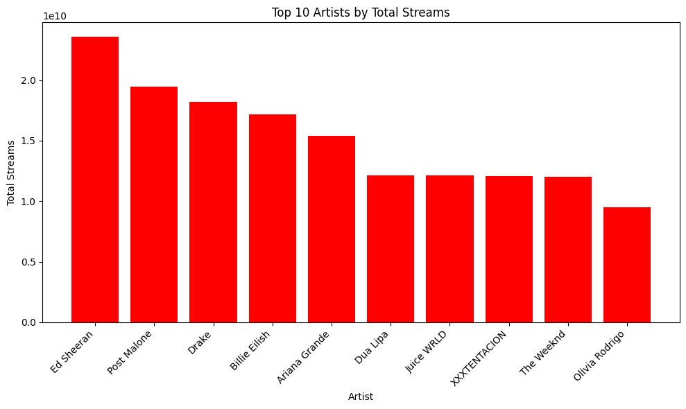

```python
top_artists = artist_streams.head(10)

# Plot the top 10 artists in a bar chart
plt.figure(figsize=(10, 6))
plt.bar(top_artists['artist'], top_artists['streams'], color='red')
plt.xlabel('Artist')
plt.ylabel('Total Streams')
plt.title('Top 10 Artists by Total Streams')
plt.xticks(rotation=45, ha='right')
plt.tight_layout()

# Show the plot
plt.show()
```

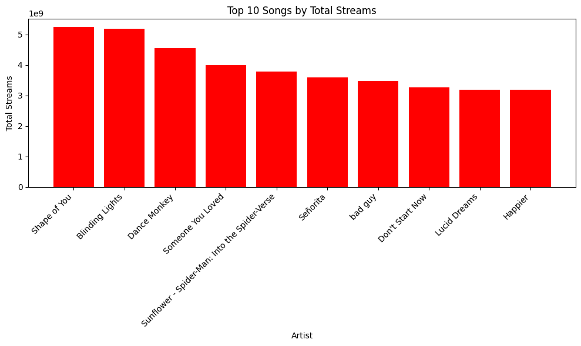

```python
top_songs = song_streams.head(10)

# Plot the top 10 artists in a bar chart
plt.figure(figsize=(10, 6))
plt.bar(top_songs['title'], top_songs['streams'], color='red')
plt.xlabel('Artist')
plt.ylabel('Total Streams')
plt.title('Top 10 Songs by Total Streams')
plt.xticks(rotation=45, ha='right')
plt.tight_layout()

# Show the plot
plt.show()
```

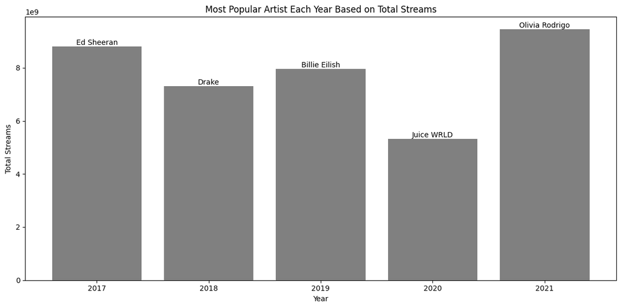

```python
# Plotting
plt.figure(figsize=(12, 6))
bars = plt.bar(top_artists_per_year['year'].astype(str), top_artists_per_year['streams'], color='grey')

# Add labels and title
plt.xlabel('Year')
plt.ylabel('Total Streams')
plt.title('Most Popular Artist Each Year Based on Total Streams')

# Add text labels for the artists
for bar, artist in zip(bars, top_artists_per_year['artist']):
    yval = bar.get_height()
    plt.text(bar.get_x() + bar.get_width()/2, yval, artist, va='bottom', ha='center')

plt.tight_layout()
plt.show()
```

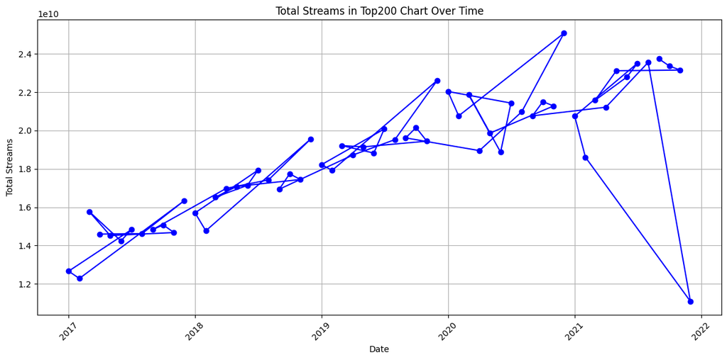

```python
# Filter the DataFrame to include only 'top200' chart
filtered_df = df[df['chart'] == 'top200']

# Aggregate streams by month and year
monthly_streams = filtered_df.groupby(['year', 'month_name'])['streams'].sum().reset_index()

# Create a datetime column for plotting
monthly_streams['datetime'] = pd.to_datetime(monthly_streams['year'].astype(str) + '-' + monthly_streams['month_name'] + '-01')

# Plotting
plt.figure(figsize=(12, 6))
plt.plot(monthly_streams['datetime'], monthly_streams['streams'], marker='o', linestyle='-', color='b')
plt.xlabel('Date')
plt.ylabel('Total Streams')
plt.title('Total Streams in Top200 Chart Over Time')
plt.xticks(rotation=45)
plt.grid(True)
plt.tight_layout()
plt.show()
```

```python
# Filter the DataFrame to include only 'top200' chart
filtered_df = df[df['chart'] == 'top200']

# Aggregate streams by month and year
monthly_streams = filtered_df.groupby(['year', 'month_name'])['streams'].sum().reset_index()

# Create a datetime column for plotting
monthly_streams['datetime'] = pd.to_datetime(monthly_streams['year'].astype(str) + '-' + monthly_streams['month_name'] + '-01')

#### 3. Create Interactive Plot

# Create an interactive line plot with Plotly
fig = px.line(monthly_streams, x='datetime', y='streams', title='Total Streams in Top200 Chart Over Time', markers=True)

# Update layout for better readability
fig.update_layout(
    xaxis_title='Date',
    yaxis_title='Total Streams',
    xaxis=dict(tickformat='%b %Y'),  # Format x-axis as month-year
    title_font_size=24,
    xaxis_title_font_size=18,
    yaxis_title_font_size=18,
    margin=dict(l=40, r=40, t=40, b=40)  # Adjust margins
)

# Show the plot
fig.show()
```

[output not shown]

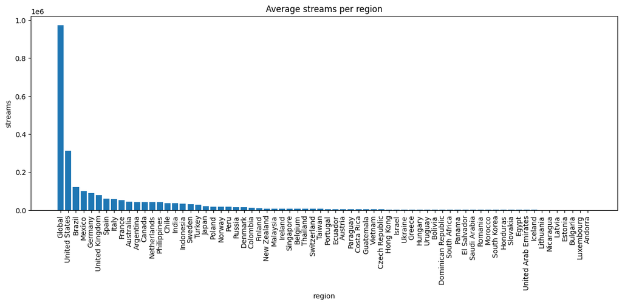

```python
df_regions = df.groupby('region', axis=0)['streams'].mean().sort_values(ascending=False)
plt.figure(figsize=(15, 5))
plt.bar(df_regions.index, df_regions.values)
plt.xticks(rotation=90)
plt.xlabel('region')
plt.ylabel('streams')
plt.title('Average streams per region')
plt.show()
```

##### Bar chart for streams per year

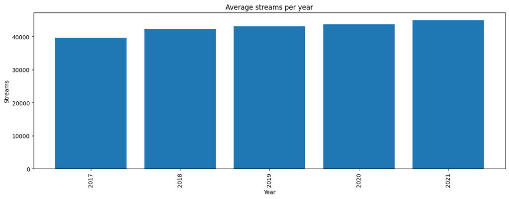

```python
#yearly total number of streams
df_yearly = df.groupby('year', axis=0)['streams'].mean().sort_values(ascending=False)
plt.figure(figsize=(15, 5))
plt.bar(df_yearly.index, df_yearly.values)
plt.xticks(rotation=90)
plt.xlabel('Year')
plt.ylabel('Streams')
plt.title('Average streams per year')
plt.show()
```

##### plot of frequence of trends

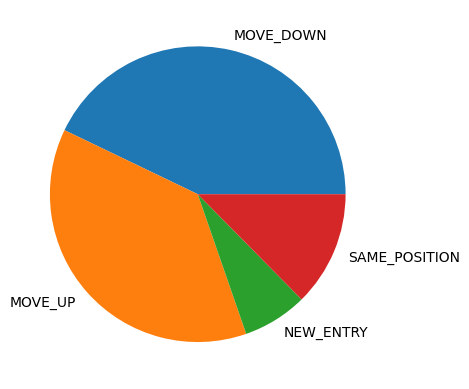

```python
df.groupby('trend').size().plot(kind='pie', color=sns.palettes.mpl_palette('Dark2'))
plt.gca().spines[['top', 'right',]].set_visible(False)
```

```python
df['trend'].value_counts()
```

```
trend
MOVE_DOWN        11220419
MOVE_UP           9801043
SAME_POSITION     3298386
NEW_ENTRY         1853637
Name: count, dtype: int64
```

##### Plot of the change in trend of the 'shape of you' song

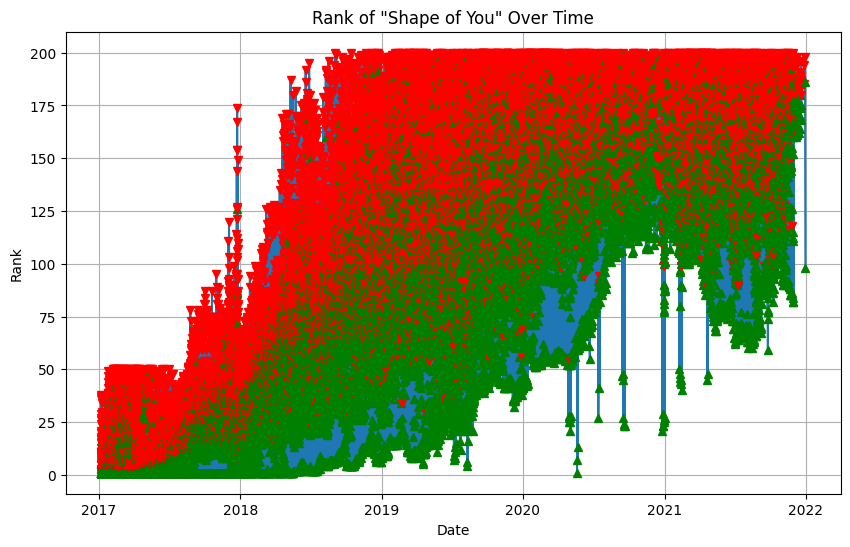

```python
shape_of_you_df = df[df['title'] == 'Shape of You']
shape_of_you_df = shape_of_you_df.sort_values('date')

# Create the line plot
plt.figure(figsize=(10, 6))  # Adjust figure size as needed
plt.plot(shape_of_you_df['date'], shape_of_you_df['rank'])
plt.xlabel('Date')
plt.ylabel('Rank')
plt.title('Rank of "Shape of You" Over Time')

# Add markers to indicate rank increases and decreases
for i in range(1, len(shape_of_you_df)):
    if shape_of_you_df['rank'].iloc[i] > shape_of_you_df['rank'].iloc[i-1]:
        plt.plot(shape_of_you_df['date'].iloc[i], shape_of_you_df['rank'].iloc[i], marker='v', color='red')  # Downward triangle for rank decrease
    elif shape_of_you_df['rank'].iloc[i] < shape_of_you_df['rank'].iloc[i-1]:
        plt.plot(shape_of_you_df['date'].iloc[i], shape_of_you_df['rank'].iloc[i], marker='^', color='green')  # Upward triangle for rank increase

plt.grid(True)
plt.show()
```

##### Top 10 repeated songs and their occurances and ranking according to popularity

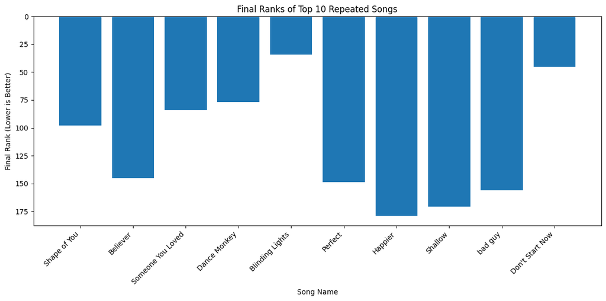

```python
top_10_songs = df['title'].value_counts().head(10).index
final_ranks = {}

# Get the final rank for each song
for song in top_10_songs:
    song_df = df[df['title'] == song]
    song_df = song_df.sort_values('date')
    final_ranks[song] = song_df['rank'].iloc[-1]  # Get the rank of the last (most recent) entry

# Create a bar chart with reversed y-axis
plt.figure(figsize=(12, 6))
plt.bar(final_ranks.keys(), final_ranks.values())
plt.xlabel('Song Name')
plt.ylabel('Final Rank (Lower is Better)')
plt.title('Final Ranks of Top 10 Repeated Songs')
plt.xticks(rotation=45, ha='right')
plt.gca().invert_yaxis()  # Invert the y-axis
plt.tight_layout()
plt.show()
```

#### 5. Building the Streamlit Dashboard

1. Add interactive elements
2. Include widgets and sidebars and dropdowns and checkboxes for user interaction
3. display visulaization
4. deploy the dashboard

```python
df.info()
```

```
<class 'pandas.core.frame.DataFrame'>
Index: 26173485 entries, 0 to 26173513
Data columns (total 12 columns):
 #   Column      Dtype
---  ------      -----
 0   title       object
 1   rank        int64
 2   date        datetime64[ns]
 3   artist      object
 4   url         object
 5   region      object
 6   chart       object
 7   trend       object
 8   streams     int64
 9   year        int32
 10  month       int32
 11  month_name  object
dtypes: datetime64[ns](1), int32(2), int64(2), object(7)
memory usage: 2.3+ GB
```

```python
df['date'] = pd.to_datetime(df['date'])  # Ensure date column is in datetime format
```

```python
df.info()
```

```
<class 'pandas.core.frame.DataFrame'>
Index: 26173485 entries, 0 to 26173513
Data columns (total 12 columns):
 #   Column      Dtype
---  ------      -----
 0   title       object
 1   rank        int64
 2   date        datetime64[ns]
 3   artist      object
 4   url         object
 5   region      object
 6   chart       object
 7   trend       object
 8   streams     int64
 9   year        int32
 10  month       int32
 11  month_name  object
dtypes: datetime64[ns](1), int32(2), int64(2), object(7)
memory usage: 2.3+ GB
```

```python
streamlit_code = """
import streamlit as st
import pandas as pd
import altair as alt
import folium
from streamlit_folium import st_folium

# Load the entire dataset to get all countries
def load_full_data(filepath):
    return pd.read_csv(filepath)

# Load the entire dataset to get the full list of countries
full_data = load_full_data('df_withmonths.csv')

# Then, subset the data for other operations
def load_data(filepath, nrows=500):
    return pd.read_csv(filepath, nrows=nrows)

# Load the data (only 500 rows)
data = load_data('df_withmonths.csv')

# Optimize Data Types (Optional)
def optimize_data(df):
    df['month'] = df['month'].astype('category')
    df['trend'] = df['trend'].astype('category')
    df['artist'] = df['artist'].astype('category')
    df['region'] = df['region'].astype('category')  # Assuming 'region' represents the country
    return df

data = optimize_data(data)
full_data = optimize_data(full_data)

# Convert the unique values to a list
country_list = full_data["region"].unique().tolist()

# Streamlit Sidebar Filters
st.sidebar.header("Filters")

# Country filter
country = st.sidebar.selectbox("Select Country", options=sorted(country_list))  # Sorting for better usability

# Filter the data by the selected country
filtered_data = data[data["region"] == country]

# Convert the unique artist and trend values to a list
filtered_artist_list = filtered_data["artist"].unique().tolist()
filtered_trend_list = filtered_data["trend"].unique().tolist()

# Artist and Trend filters based on filtered country data
artist = st.sidebar.multiselect("Select Artist", options=sorted(filtered_artist_list), default=filtered_artist_list)
trend = st.sidebar.multiselect("Select Trend", options=filtered_trend_list, default=filtered_trend_list)

# Further filter the data by the selected artist and trend
filtered_data = filtered_data[(filtered_data["artist"].isin(artist)) & (filtered_data["trend"].isin(trend))]

# Display Data Table
st.write(f"## Spotify Top Tracks in {country}")
st.dataframe(filtered_data.head(100))  # Display only the first 100 rows

# Visualizations
# Bar Chart: Rank Distribution by Artist
st.write("## Rank Distribution by Artist")
rank_chart = alt.Chart(filtered_data).mark_bar().encode(
    x='artist:N',
    y='rank:Q',
    color='artist:N',
    tooltip=['title', 'rank', 'streams']
).interactive()
st.altair_chart(rank_chart, use_container_width=True)


# Pie Chart: Trend Proportion
st.write("## Trend Proportion")
trend_chart = alt.Chart(filtered_data).mark_arc().encode(
    theta=alt.Theta(field="streams", type="quantitative"),
    color=alt.Color(field="trend", type="nominal"),
    tooltip=['trend', 'streams']
).interactive()
st.altair_chart(trend_chart, use_container_width=True)

# Display Links to Spotify Tracks
st.write("## Spotify Links")
for i, row in filtered_data.iterrows():
    st.write(f"[{row['title']}]({row['url']}) by {row['artist']}")

"""

# Write the Streamlit code to a Python script
with open('spotify_dashboard.py', 'w') as f:
    f.write(streamlit_code)

print("Streamlit code saved to 'spotify_dashboard.py'")
```

```
Streamlit code saved to 'spotify_dashboard.py'
```

```python
!streamlit run spotify_dashboard.py
```

```
^C
```